# Homework 6

**Due: 2022-3-17, 10:30am (before the class)**

### Analysis Based on Score Dataset

We will use the **score dataset**, which we talked about as an example during the class. The data can be downloaded from [blackboard](https://blackboard.uthsc.edu/).

Suppose we are studying three different teaching methods for a course (independent variable). We also have student satisfaction scores and test scores (dependent variables). We want to determine whether the mean scores for satisfaction and tests differ between the three teaching methods.

You can use the commands `read.csv()` to read data in R.

```
##   Method  Test Satisfaction
## 1      1 3.000        3.001
## 2      1 2.990        2.994
## 3      1 3.041        3.032
## 4      1 3.063        3.059
## 5      1 3.035        3.026
## 6      1 3.009        3.003
```

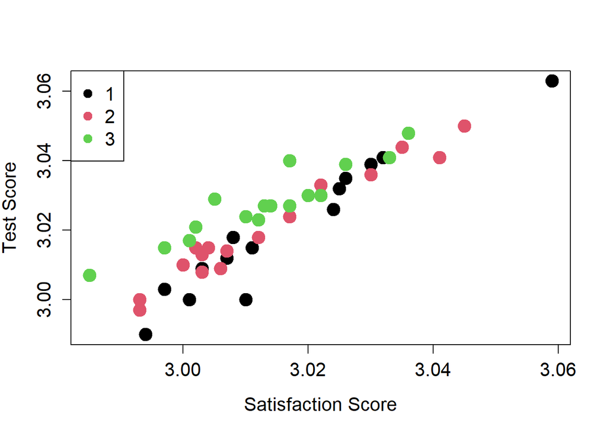

```r
# Scatter plot
plot(
  x = dat$Satisfaction,
  y = dat$Test,
  pch = 19,
  col = factor(dat$Method),
  xlab = "Satisfaction Score",
  ylab = "Test Score",
  cex=2,
  cex.axis=1.3,
  cex.lab=1.3
)
# Legend
legend("topleft",
       legend = levels(factor(dat$Method)),
       pch = 19,
       col = factor(levels(factor(dat$Method))),
       cex = 1.3)
```

1. (10%) Please calculate the mean and standard deviation of `Satisfaction` and `Test` for each `Method`.
2. (10%) Please apply MANOVA to test whether the mean scores for satisfaction and test differ between the three teaching methods.
3. (10%) Please apply one-way ANOVA to test the mean differences between teaching methods of satisfaction score and test score, separately.

### Analysis Based on Plant Dataset

Please download the [plant dataset](https://reneshbedre.github.io/assets/posts/ancova/manova_data.csv). Suppose we have a dataset of various plant varieties (`plant_var`) and their associated phenotypic measurements for plant heights (`height`) and canopy volume (`canopy_vol`). We want to see if plant heights and canopy volume are associated with different plant varieties using MANOVA.

4. (15%) Please calculate the mean and standard deviation of `height` and `canopy_vol` for each `plant_var`. Plot to visualize if plant heights and canopy volume are associated with different plant varieties using MANOVA.
5. (20%) Please apply MANOVA to test whether the mean of plant heights and canopy volume differ between the four plant varieties. Please interpret the output.
6. (20%) Please apply one-way ANOVA to test the mean differences between plant varieties of plant heights and canopy volume, separately. Please interpret the output.
7. (15%) Use the `TukeyHSD()` function to obtain all pairwise differences between plant varieties of plant heights.